# CUNY 607 Project, Critic Rating to Music Listenership

Todd Weigel

December 18, 2016

## Do Critical Reviews of Music Relate to Actual Listenership?

##### There are plenty of music review sites out there (as well as ones for movies, books, games, etc.). We can find hundreds of online and print magazine and newspapers that have reviews, review aggregration sites like Metacritic, as well as sites like AllMusic, which has critical reviews of literally hundreds of thousands of music albums. So clearly, one might wonder if so many people are critiquing music, does it influence what people might listen too? Obviously causation is an impossible thing to prove via pulling data from the web, so this effort will concentrate on a simpler question, do the ratings of critics (which presumably corresponds to the text in their written reviews), have any correlation with what music people listen? Basically does music that critics rate highly, correspond with increased listening from the public at large?

##### To do this research two websites will be used that contain great quantities of data to mine. AllMusic.com (http://www.allmusic.com/) as mentioned has reviews of essentially all major popular works (Bryan Adams excepted, apparently he has some issue with All Music, and an interesting google search…), down to reviews of things that are extraordinarily obscure. So this site was chosen to be the source for critical ratings. The site last.fm (http://www.last.fm) has an api, which among many other things allows one to retrieve the number of listeners to a particular album, as well as the number of plays for that album.

#### Hypothesis

##### The basic null hypothesis for this research would be that critics do not influence listenership, and the alternate would be that critics do influence listenership, i.e.:

- H<sub>0</sub> $\mu$<sub>diff</sub> = 0: Critics do **not** influence listening habits.
- H<sub>A</sub> $\mu$<sub>diff</sub> $\neq$ 0: Critics do influence listening habits.

##### Not to prejudge the research, but some of the inherent cynicism in the author leads him to believe we will not be rejecting the null hypothesis. And if pictures are worth some number of words, here are a couple of pairs:

[figure not shown]

[figure not shown]

### 4 Stars, 6k listeners:

[figure not shown]

[figure not shown]

### Components of the project.

##### Source Code “readAllMusic.R”

```r
library(XML)
library(stringr)
library(RCurl)
library(selectr)
library(rvest)
library(mongolite)
#library(jsonlite)
source("utilities.r")


seedURL <-"http://www.allmusic.com/artist/nick-cave-mn0000397880"
setwd("L:\\school\\cuny\\607\\finalproj - Mongo")

mongoURL <- "mongodb://localhost:27017/MusicScrapings"
mongoDB <- "MusicScrapings"
collection <- "AllMusic"

# Mongo Section -------


getAlbumsBefore2000 <- function()
{
    mongoConnection("AllMusic")$find('{"Year": { "$lt": "2000" } }')
}

getAlbums <- function()
{
    mongoConnection("AllMusic")$find()
}


getArtistURLs <- function()
{
    return(mongoConnection("Artists")$find(fields = '{"_id" : 0, "ArtistsURL" : 1}'))
}

# allmusic Scraping Section ----

getRootHTML <- function(artistURL)
{
    html <- getURL(artistURL,
                   useragent = str_c(R.version$platform,
                                     R.version$version.string,
                                     set=", "))
    root <- NULL
    try(root <- xmlRoot(htmlParse(html)))

    return(root)
}

getArtistRepository <- function(artistURL)
{
    artistRootHTML <- getRootHTML(str_c(artistURL, "/discography"))
    #exit if nothing returned
    if (is.null(artistRootHTML)) return(NULL)

    artistName <- xpathApply(artistRootHTML,'//*[@id="cmn_wrap"]/div[1]/div[2]/header/div/hgroup/h1', xmlValue )
    artistName <- str_replace_all(artistName, "\n +|  +", "")
    #header <- xpathSApply(artistRootHTML, "//table/tr/th", xmlValue)

    #get year
    #year <- xpathApply(artistRootHTML, '//*[contains(concat( " ", @class, " " ), concat( " ", "year", " " ))]', xmlValue)
    year <- str_trim(xpathApply(artistRootHTML, '//*[@id="cmn_wrap"]/div[1]/div[2]/section/table/tbody/tr/td[3]', xmlValue))

    #get album names
    albums <- xpathSApply(artistRootHTML, '//*[@id="cmn_wrap"]/div[1]/div[2]/section/table/tbody/tr/td[4]/a[1]', xmlValue)

    #rating is 2nd attr of this section
    criticRatings <- xpathSApply(artistRootHTML, '//*[@id="cmn_wrap"]/div[1]/div[2]/section/table/tbody/tr/td[6]', xmlAttrs)[2,]
    #ratings is first numeric value, and is from 0-9, so add 1 to make 1-10  (actual values on screens are 5 stars, which can have 1/2 values)
    criticRatings <- as.numeric(str_extract(criticRatings, "[[0-9]]")) + 1


    # #user ratings are not "in the html_doc...", they are a css class, that is probably "jqueried" when the page is loaded
    # userRatings <- xpathSApply(artistRootHTML, '//*[@id="cmn_wrap"]/div[1]/div[2]/section/table/tbody/tr/td[7]', xmlAttrs)[2,]
    # userRatings <- as.numeric(str_extract(userRatings, "[[0-9]]")) + 1


    df <- data.frame(artistName, year, albums, criticRatings, stringsAsFactors = FALSE)
    colnames(df) <- c("Artist", "Year", "Album", "critcRatings")#, "userRatings")
    return(df[complete.cases(df),])
}


#pass in list of artist allmusic URL's returns df with artists albums, and ratings, both critics and user
addRatingsToArtists <- function(lArtistsURL)
{
    df <- getArtistRepository(lArtistsURL[1])
    for(idx in 2:length(lArtistsURL))
    {
         df<- rbind(df, getArtistRepository(lArtistsURL[idx]))
         if ((idx %% 100) == 0) print (str_c("iteration " , idx))  #since this can take forever...status
    }

    return(df)

}


#returns a list of artists "related" the artist passed in
getRelatedArtists <- function(artistURL)
{
    relatedRootHTML <- getRootHTML(str_c(artistURL, "/related"))
    relatedAddr <- NULL
    if (!is.null(relatedRootHTML))
    {
        relatedAddr <- xpathSApply(relatedRootHTML, '//*[@id="cmn_wrap"]/div[1]/div[2]/section[1]/ul/li/a', xmlAttrs)[1,]
    }
    return(relatedAddr)
}


#recursive, list will grow fast as well as execution time if depth is much higher than small single digits
#note artists param is meant to be used by the function itself during recursion, the initial call does not need to populate
buildArtistList <- function(url, depth, artists = url)
{
    #print("call build artist2")
    related <- getRelatedArtists(url)
    if (is.null(related) | depth ==0)
        return(related)

    depth <- depth -1

    while(length(related) > 0)
    {
        if(length(artists[artists == related[1]]) < 1)
        {
            artists <- unique(c(artists, buildArtistList3(related[1], depth, c(related[1], artists))))

        }
        related <- related[-1]
    }

    return(artists)
}



#6degreesofBacon ----

perform6DegreesOfBacon <- function()
{
    baconList <- buildArtistList("http://www.allmusic.com/artist/the-bacon-brothers-mn0000044295/", 6)
    dfBacon <- as.data.frame(baconList, stringsAsFactors = F)
    colnames(dfBacon) <- "ArtistsURL"
    dfBacon$ArtistName <- str_extract(dfBacon[,], "artist/.*") %>%
        str_replace("artist/", "") %>%
        str_replace("-mn.*", "") %>%
        str_replace_all("-", " ") %>%
        simpleCap()
    conn <- mongoConnection("SixDegreeBacon")
    insertMongo(conn, dfBacon, T)

}
```

##### Source Code “lastFM_api2.R”

```r
setwd("L:\\school\\cuny\\607\\finalproj - Mongo")
library(RCurl)
library(XML)
library(stringr)
library(RJSONIO)
library(mongolite)
library(parallel)
source("utilities.R")


#sample syntax
#http://ws.audioscrobbler.com/2.0/?method=album.getinfo&api_key=YOUR_API_KEY&artist=Cher&album=Believe&format=json

baseURL <- "http://ws.audioscrobbler.com/2.0/?method=album.getinfo&api_key="
setwd("L:\\school\\cuny\\607\\finalproj - Mongo")
apiFile <- "lastfmapi.txt"
apiKey <- (scan(apiFile, what = "character", quiet = T))


# Mongo Section -------

mongoURL <- "mongodb://localhost:27017/MusicScrapings"
mongoDB <- "MusicScrapings"
fmCollection <- "LastFMData"

getLastFM <- function()
{
    return(mongoConnection("LastFMData")$find())
}


#Scraping Section ---



parseJSON <-function (contents)
{
    results <- NULL
    try( results <-  fromJSON(contents, simplify = FALSE))

    return(results)
}

getAPIString <- function(artist, album)
{
    concatURI <- str_c(baseURL, apiKey,  "&artist=", artist, "&album=", album, "&format=json")
    concatURI <- str_replace_all(concatURI, " ", "%20")  #replace space with encoding
    return(concatURI)
}

readLastFM_JSON <-function(vArtistAlbum)
{
    concatURI <- str_c(baseURL, apiKey,  "&artist=", vArtistAlbum[1], "&album=", vArtistAlbum[2], "&format=json")
    concatURI <- str_replace_all(concatURI, " ", "%20")   #replace space with encoding
    return(parseJSON(getURI(concatURI)))
}

#populates table in mongo with results from the album info method of the lastfm api
populateLastFMCollection <- function(vArtistAlbum, mConn)
{
    results <- readLastFM_JSON(vArtistAlbum)
    if(!is.null(results))
    {
        insertMongo(mConn, results)
    }
}


#populates the count of listens and plays for a given artist/album combination
#currently not used in project as whole
getListenPlayCounts <- function(artist, album)
{
    #key <- readApiKeyFromFile("lastfmapi.txt")
    results <- readLastFM_JSON(artist, album)
    return(c(results$album$listeners, results$album$playcount))

}


# Testing Code -----

populateFMMongoFromFile <- function()
{
    insertMongo(mongoConnection(fmCollection), read.csv("meshed.csv", stringsAsFactors = F), T)
}
```

##### Source Code “meldRatingsVUse.R”:

```r
setwd("L:\\school\\cuny\\607\\finalproj - Mongo")
source("lastFM_API2.r")
source("readAllMusic.r")
source("utilities.r")
library(parallel)
#library(snow)

seedURL <-"http://www.allmusic.com/artist/nick-cave-mn0000397880"
setwd("L:\\school\\cuny\\607\\finalproj - Mongo")
#mongoURL <- "mongodb://localhost:27017/MusicScrapings"
#mongoDB <- "MusicScrapings"


getCompleteFMCases <- function()
{
    df <- mongoConnection(fmCollection)$find(fields = '{"_id" : 0, "album.name" : 1, "album.artist" :1,
                                             "album.listeners": 1, "album.playcount" : 1  }')
    #above returns df of 1 column that is vector of 4, transform
    df <- data.frame(cbind(unlist(df[,1][1], use.names = F),
                           unlist(df[,1][2], use.names = F),
                           unlist(df[,1][3], use.names = F),
                           unlist(df[,1][4], use.names = F)),
                     stringsAsFactors = F)
    cNames <- c("Album", "Artist", "Listeners",  "Plays")
    colnames(df) <- cNames

    df <- df[complete.cases(df),]
    return(df[complete.cases(df),])
}


# Calls function in readAllMusic.r, to get a list of related artists and then pops in mongo collection
# params:
#   * seed_URL, starting allmusic artist page
#   * collection, mongo colleciton name to insert the generated list
#   * depth, how many levels do we want go down, for related artists
#   * overwrite, overwrite or append to mongo collection
populateArtistCollection <- function(seedURL, collection, depth, overWrite = F)
{
    artists <- buildArtistList(seedURL, depth)
    dfArtists <- as.data.frame(artists, stringsAsFactors = F)
    colnames(dfArtists) <- "ArtistsURL"
    #pull artist name from URL
    dfArtists$ArtistName <- lapply(dfArtists[,1], function(x) str_extract(x, "artist/.*") %>%
                                       str_replace("artist/", "") %>%
                                       str_replace("-mn.*", "") %>%
                                       str_replace_all("-", " ") %>%
                                       simpleCap())

    conn <- mongoConnection(collection)
    insertMongo(conn, dfArtists, overWrite)
}


#calls function in readAllMusic.r to get a list of albums per artist, and critic ratings
#populates mongo collection with that info
# params
# * vArtistUrls, char vector of artist urls to allmusic
# * collection is name of mongo collection to store results
# * overwrite, overwrite or append to mongo collection
populateArtistRepository <- function(vArtistURLs, collection, overWrite = F)
{
    dfArtistRepository <- addRatingsToArtists(vArtistURLs)
    conn <- mongoConnection(collection)
    insertMongo(conn, dfArtistRepository, overWrite)
}

#can't resist the pun
meshAMFM <-function(dfAM, dfFM)
{

    conn <- mongoConnection("AMFMCombined2")

    dfAMUpper <- dfAM
    dfAMUpper$Artist <- toupper(dfAM$Artist)
    dfAMUpper$Album <- toupper(dfAM$Album)
    dfMesh <- NULL
    for(idx in 1:nrow(dfFM))
    {
        AMfull <-unique(dfAM[dfAMUpper$Artist == toupper(dfFM$Artist[idx])
                       & dfAMUpper$Album == toupper(dfFM$Album[idx])
                       ,])[1,]
        AM <- cbind(AMfull$critcRatings, AMfull$Year)

        if(complete.cases(AMfull))
        {
            amfm <- cbind(dfFM[idx,], AM)
            colnames(amfm)[colnames(amfm) == 1] <- "CriticRating"
            colnames(amfm)[colnames(amfm) == 2] <- "Year"
            insertMongo(conn, amfm)
        }
    }
}


# ----


populateFMDataFromAMTable <- function()
{
    albums <- getAlbums()
    cluster <- makeCluster(9)
    clusterEvalQ(cluster, {
        source("lastFM_API2.r")
        source("readAllMusic.r")
        source("utilities.r")
        library(parallel)
    })
    parApply(cluster, albums[,c("Artist", "Album")], 1, populateLastFMCollection, mongoConnection(fmCollection))
    stopCluster(cluster)
}

#These 6 statements below do all the populating of the tables in mongo, with arist, and album info,
#with six levels of artists references, i.e, start with seed artist, get all artists which allmusic
#thinks are related, get all the related artists to those artists, and do 5 more times

#populateArtistCollection(seedURL, "Artists", 6, T)
#populateArtistRepository(getArtistURLs()[,1], "AllMusic")
#populateFMDataFromAMTable()
#dfAllMusic <- getAlbums()
#dfLastFM <- getCompleteFMCases()
#meshAMFM(dfAllMusic,dfLastFM)
```

##### Source Code “analysisRatingsListens.R”:

```r
library(mongolite)
library(stringr)
setwd("L:\\school\\cuny\\607\\finalproj - Mongo")
source("utilities.r")


mongoURL <- "mongodb://localhost:27017/MusicScrapings"
mongoDB <- "MusicScrapings"
fmCollection <- "LastFMData"


getAlbumYear <- function(album, artist)
{
    #mongoConnection("AllMusic")$find('{"Year": { "$lt": "2000" } }')

    artist<- str_replace_all(artist, '"', '')
    album <- str_replace_all(album, '"', '')

    q <- str_c('{"Artist" : { "$eq" : "' , artist, '"}}' )


    df <- mongoConnection("AllMusic", verbosity = F)$find(query = q,
                                     fields = '{"_id" : 0, "Year": 1, "Album": 1 }')

    if(nrow(df)>0)
        return(as.numeric(unique(df[toupper(df$Album) == toupper(album),][1,1])))
    else
        return(NA);



}


#This is a horrible way to do it :(  Mongo is way to slow for this kind of work (at least without indexing and other tuning)
#will do once and add a table (aka collection)
#not actually used
addYears <- function(df)
{
    df$Year <- NA
    df$Year <- mapply(getAlbumYear, df$Album, df$Artist)
    return(df)

}



subsetByLargeAlbumCount <- function()
{
    dfReturn <- NULL
    distinctArtists <- unique(artists$Artist)
    for(idx in 1:length(distinctArtists))
    {
        dfArtist <- artists[artists$Artist == distinctArtists[idx],]
        if(nrow(dfArtist)>7)
        {
            dfReturn <- rbind(dfReturn, dfArtist)
        }
    }
    return(dfReturn)
}


individualRegression <- function(dfArtists)
{
    dfArtistsCor <- NULL

    distinctArtists <- unique(dfArtists$Artist)


    for(idx in 1:length(distinctArtists))
    {
        df <- dfArtists[dfArtists$Artist == distinctArtists[idx],]
        lmL <- lm(df$Listeners ~ df$CriticRating)
        lmP <- lm(df$Plays ~ df$CriticRating)
        sumL <- summary(lmL)
        sumP <- summary(lmP)
        sumL$df[2]
        dfCor <- cbind(distinctArtists[idx],  cor(df$CriticRating, df$Listeners), cor(df$CriticRating, df$Plays),
                       lmL$coefficients[1], lmL$coefficients[2], sumL$df[2], sumL$r.squared,
                       lmP$coefficients[1], lmP$coefficients[2], sumP$df[2], sumP$r.squared)


        dfArtistsCor <- rbind(dfArtistsCor, dfCor)
    }
    cNames <- c("Artist", "CriticVListnerCorr", "CriticVPlayCorr", "ListenerIntercept",
                "ListenerCoefficient", "DFListener", "RSQListener",
                "PlayIntercept", "PlayCoefficient", "DFPlay", "RSQPlay")
    colnames(dfArtistsCor) <- cNames
    return(as.data.frame(dfArtistsCor, stringsAsFactors = F))
}

# sample analysis code ----

#
# artists <- mongoConnection("AMFMCombined")$find()
# artists$Year <- as.numeric(artists$Year)
# artists$Listeners <- as.numeric(artists$Listeners)
# artists$Plays <- as.numeric(artists$Plays)
# artists$CriticRating <- as.numeric(artists$CriticRating)
# cor(artists$CriticRating, artists$Listeners)
# cor(artists$CriticRating,artists$Plays)
# lmArtistsL <- lm(artists$Listeners ~ artists$CriticRating)
# lmArtistsP <- lm(artists$Plays ~ artists$CriticRating)
# summary(lmArtistsL)
# summary(lmArtistsP)
#
# median(artists$Listeners)
# median(artists$Plays)
#
# options(scipen = 5)
# hist(artists$Listeners, breaks= 30, ylim = c(0, 10000), xlim = c(0,1000000), xlab = "Listeners")
# hist(artists$Plays, breaks= 50, ylim = c(0, 10000), , xlim = c(0,10000000), xlab = "Plays")
#multiAlbumArtists <- subsetByLargeAlbumCount()
# artistsCor <- individualRegression(multiAlbumArtists)
# sum(as.numeric(artistsCor$CriticVListnerCorr)) / nrow(artistsCor)
# sum(as.numeric(artistsCor$CriticVPlayCorr)) / nrow(artistsCor)
# sum(as.numeric(artistsCor$RSQListener)) / nrow(artistsCor)
# sum(as.numeric(artistsCor$RSQPlay)) / nrow(artistsCor)
```

##### Source Code “utilities.R”:

```r
library(mongolite)
mongoURL <- "mongodb://localhost:27017/MusicScrapings"
mongoDB <- "MusicScrapings"
#from "R" help in toupper function
simpleCap <- function(x)
{
    s <- strsplit(x, " ")[[1]]
    paste(toupper(substring(s, 1, 1)), substring(s, 2),
          sep = "", collapse = " ")
}


mongoConnection <- function(coll = collection, verbosity = T)
{
    return(mongo(coll, mongoDB, mongoURL, verbose = verbosity ))
}

insertMongo <-function(mongConn, df, drop = F)
{
    if(drop)
    {
        try(mongConn$drop())
    }
    mongConn$insert(df)

}
```

- MongoDB Collections
  - Artists, has fields of ArtistURL and Artist Name
  - AllMusic, has fields of “Artist”, “Year” (of album), “Album”, and “CriticRatings”
  - LastFMData, holds, the album related info from the lastfm api. Has field of album, with relavant sub fields being “name”, “artist”, “listeners”, and “playcount”.
  - AMFMCombined, is the collection used for analysis. Contains fields, Album, Artist, Listeners, Plays, CriticRating, and Year.

### The Biggest Project Problem and How It Was Overcome

#### And a Cool Ability Learned in R

#### Web Scraping is Slow…

[figure not shown]

#### Enter Parallel Processing

##### The biggest problem encountered was the sheer length of time the webscraping and pulling of data from the API–this was an extremely time consuming process. Two solutions were available, one, was to consume less data, the other was to consume it faster. While I didn’t necessarily need all the data I pulled to work on the project, clearly, being able to pull large amounts of data quickly is useful. The solution I found is the **parallel** package in R. And this does what it’s name implies, it allows you to run a task over a dataset, (or vector or matrix), with multiple items processing at once.

#### What’s it good for:

##### This parallel process isn’t going to compensate if your CPU is already running to max capacity, but if you are processing things with a lot of overhead (network tasks, db reading), this can help a lot. My ability to quickly use the lastfm API was not CPU or network bound, but rather the overhead of making a connection, being authenticated, transferring data over the internet, and so forth. Running in parallel reduced calling time by a factor nearly equal to the number of parallel processes started.

#### It’s actually really simple :)

##### The code to use it in this project is below, and the package is actually really simple to use once it is understood. Basically to get it up and running requires only four functions:

- makeCluster, with a param of how many clusters (AKA how many parallel processes) one wants to run.
- clusterEvalQ, here you load a bunch of commands to “bootstrap” each cluster, basically allocating the environment with what one needs to execute your parallel tasks.
- parApply (or similar parSapply, parLapply, etc.), which is a parallel version of apply, with the same parameters except you pass it your group of clusters from the makeCluster function.
- stopCluster, stops the clusters from running. If you start your clusters in a function and don’t do this, they will run until you terminate R Studio (or otherwise terminate the root from where these started), as you no longer have a reference to stop them.

#### Things to Know:

There are a couple of things to understand with this process. The first, is each cluster starts R “naked” basically, as if you had just started R itself, and has no libraries loaded, and no functions and variables defined. In Windows to make sure your cluster has the environment it needs, you need to pass commands to load them up, see the code below with the source and library calls specified. In Unix (or Mac), the process is simpler, you can run a function, makeForkCluster, which will load (fork) all your current environment variables into the new clusters.

The second, and this is an really **easy way to force yourself into an instant reboot** if messed up, is to make sure you don’t call your process to create clusters from within the files being sourced (or even in the code you are executing in the clusters). Basically, you end up in an infinite loop of the code calling itself and spawning new processes, and it isn’t likely you will be fast enough to terminate them in task manager before 2 more have spawned.

#### Sample code from project, that implements parallel processing:

```r
populateFMDataFromAMTable <- function()
{
    albums <- getAlbums()
    cluster <- makeCluster(9)
    clusterEvalQ(cluster, {
        source("lastFM_API2.r")
        source("readAllMusic.r")
        source("utilities.r")
        library(parallel)
    })
    parApply(cluster, albums[,c("Artist", "Album")], 1, populateLastFMCollection, mongoConnection(fmCollection))
    stopCluster(cluster)
}
```

#### Here is how it looks in Windows Task Manager:

[figure not shown]

### Statistical Analysis:

##### Let’s look at how the critical ratings and listenership correlate. We will use the data from the AMFMCombined table to do our analysis.

```r
source("utilities.r")
artists <- mongoConnection("AMFMCombined", verbosity = F)$find()
artists$Year <- as.numeric(artists$Year)
artists$Listeners <- as.numeric(artists$Listeners)
artists$Plays <- as.numeric(artists$Plays)
artists$CriticRating <- as.numeric(artists$CriticRating)
```

##### Let’s first look at the correlation between both the number of actual listeners to an album, with regards to the critic rating from AllMusic, and then the equivalent between actual times played of an album, versus the critic rating.

#### Correlation Rating V Listeners

```r
cor(artists$CriticRating, artists$Listeners)
```

```
## [1] 0.1338362
```

#### Correlation Rating V Plays

```r
cor(artists$CriticRating,artists$Plays)
```

```
## [1] 0.1081859
```

##### Looks somewhat promsing as the correlation is positive, although we are talking just a little over 10%. So lets dig some more and fit a linear model.

```r
lmArtistsL <- lm(artists$Listeners ~ artists$CriticRating)
lmArtistsP <- lm(artists$Plays ~ artists$CriticRating)
```

#### Summary of LM for Rating V Listeners

```r
summary(lmArtistsL)
```

```
##
## Call:
## lm(formula = artists$Listeners ~ artists$CriticRating)
##
## Residuals:
##     Min      1Q  Median      3Q     Max
##  -68891  -43426  -26801   -6077 2619352
##
## Coefficients:
##                      Estimate Std. Error t value Pr(>|t|)
## (Intercept)          -35771.2     2691.8  -13.29   <2e-16 ***
## artists$CriticRating  10466.2      377.9   27.70   <2e-16 ***
## ---
## Signif. codes:  0 '***' 0.001 '**' 0.01 '*' 0.05 '.' 0.1 ' ' 1
##
## Residual standard error: 119400 on 42055 degrees of freedom
## Multiple R-squared:  0.01791,    Adjusted R-squared:  0.01789
## F-statistic:   767 on 1 and 42055 DF,  p-value: < 2.2e-16
```

#### Summary of LM for Rating V Plays

```r
summary(lmArtistsP)
```

```
##
## Call:
## lm(formula = artists$Plays ~ artists$CriticRating)
##
## Residuals:
##      Min       1Q   Median       3Q      Max
## -1105110  -720314  -397796  -184332 66767853
##
## Coefficients:
##                      Estimate Std. Error t value Pr(>|t|)
## (Intercept)           -662386      56414  -11.74   <2e-16 ***
## artists$CriticRating   176750       7920   22.32   <2e-16 ***
## ---
## Signif. codes:  0 '***' 0.001 '**' 0.01 '*' 0.05 '.' 0.1 ' ' 1
##
## Residual standard error: 2502000 on 42055 degrees of freedom
## Multiple R-squared:  0.0117, Adjusted R-squared:  0.01168
## F-statistic:   498 on 1 and 42055 DF,  p-value: < 2.2e-16
```

#### Promsing Results?

##### At first glance this looks promising. Both summaries show a coefficient that has a large number attached to it, about 10,000 for listeners and 176000 for plays, and both of the PR values for those are essentially nil. **BUT**, look at the R-Sqaured value, it is under 2% for each case, meaning the critics ratings explain next to nothing regarding the values of the listeners and plays of a given album. Looking at the Intercept being highly negative for both cases likely explains a lot.

##### Both distributions (see histograms below) are extremely right skewed (also implying extreme cases), which does perhaps affect the good fitting of a line model, and the **extreme** difference between the mean and median also demonstrate this.

```r
library(stringr)
options(scipen = 5)
print(str_c("Median Listeners: ", round(median(artists$Listeners),0), " vs mean: ", round(mean(artists$Listeners),0)))
```

```
## [1] "Median Listeners: 2269 vs mean: 37016"
```

```r
print(str_c("Median Plays: ", round(median(artists$Plays),0), " vs mean: ", round(mean(artists$Plays),0)))
```

```
## [1] "Median Plays: 19471 vs mean: 566826"
```

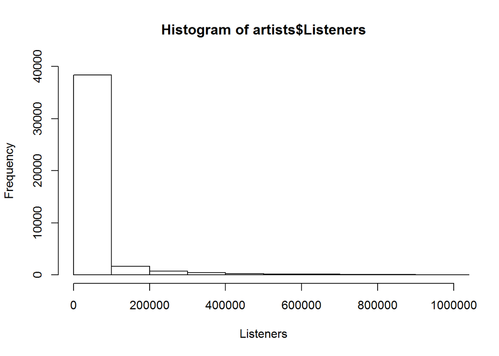

```r
hist(artists$Listeners, breaks= 30, ylim = c(0, 40000), xlim = c(0,1000000), xlab = "Listeners")
```

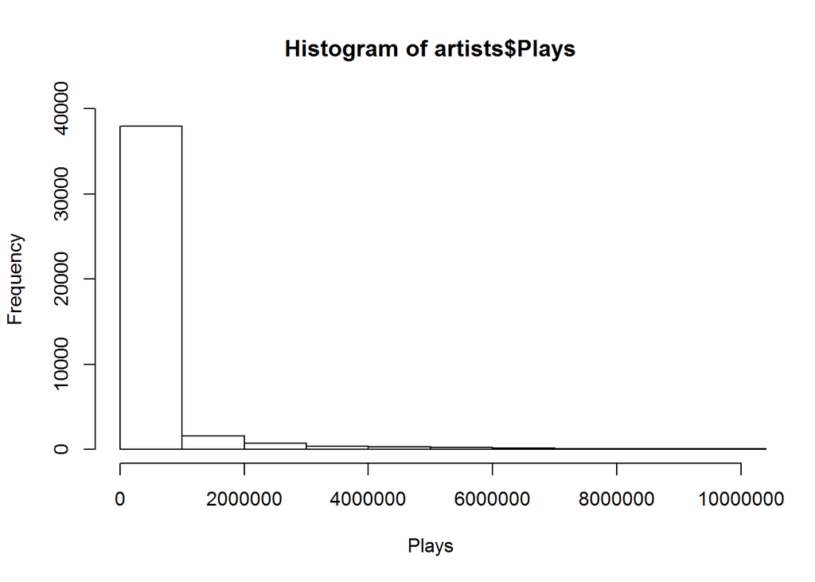

```r
hist(artists$Plays, breaks= 50, ylim = c(0, 40000), , xlim = c(0,10000000), xlab = "Plays")
```

##### Doing a plot of the data, also doesn’t really give us any confidence that we are seeing a correlateion:

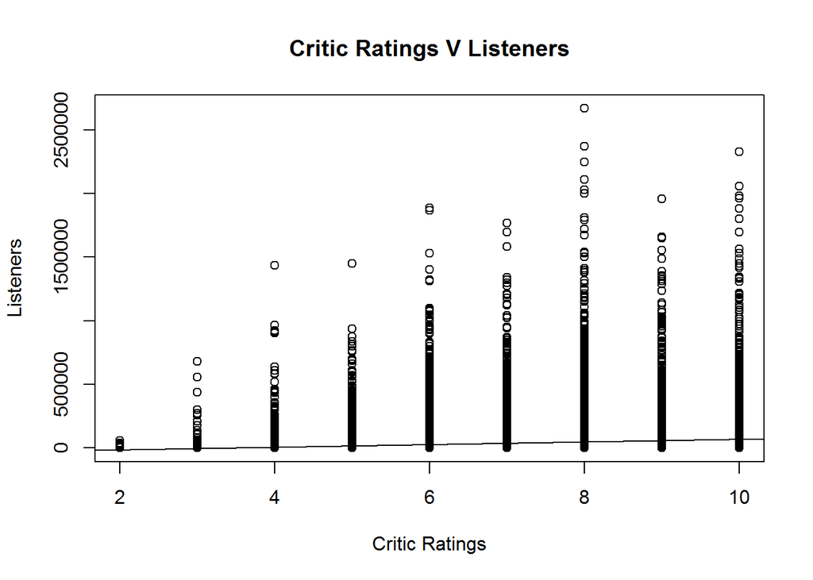

```r
  plot(artists$Listeners ~ artists$CriticRating, xlab = "Critic Ratings", ylab = "Listeners", main = "Critic Ratings V Listeners")
  abline(lmArtistsL)
```

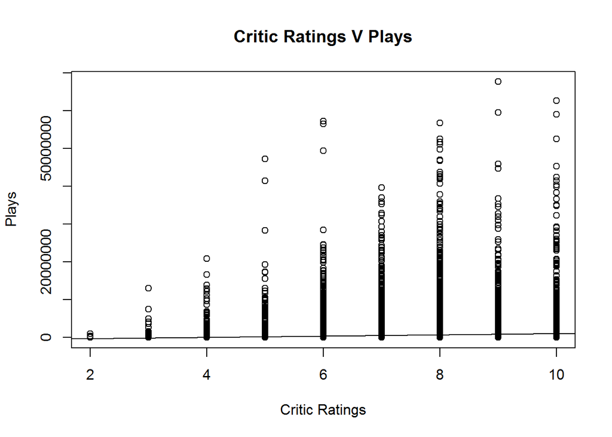

```r
  plot(artists$Plays ~ artists$CriticRating, xlab = "Critic Ratings", ylab = "Plays", main = "Critic Ratings V Plays")
  abline(lmArtistsP)
```

#### Conclusion

##### So any realistic assessment of this relationship, is that even if the summary statistics showed some slight correlation between critical ratings and listeners or plays of albums, the influence is so small as to be realistically meaningless.

#### Another Thought…

##### What might be more interesting though, is whether there is a correlation for a given artist’s works and the ratings of albums given by critics. For music as a whole, obviously many factors play into the an analysis, clearly very popular artists are going to get more plays for any of their works, just because they are a known entity and better promoted, whereas lesser known artists perhaps can live in obscurity even if talented as know one knows about them.

#### So some additional analysis was done, by creating a data table of the correlation between various albums of a given artist, and the critical rating of each of them.

#### While we are not going to do a full analysis of this data, we will show some quick statistics that do prove more interesting than the analysis at large did.

##### Here is the source to do that individualized regression.

```r
subsetByLargeAlbumCount <- function()
{
    dfReturn <- NULL
    distinctArtists <- unique(artists$Artist)
    for(idx in 1:length(distinctArtists))
    {
        dfArtist <- artists[artists$Artist == distinctArtists[idx],]
        if(nrow(dfArtist)>7)
        {
            dfReturn <- rbind(dfReturn, dfArtist)
        }
    }
    return(dfReturn)
}


individualRegression <- function(dfArtists)
{
    dfArtistsCor <- NULL

    distinctArtists <- unique(dfArtists$Artist)


    for(idx in 1:length(distinctArtists))
    {
        df <- dfArtists[dfArtists$Artist == distinctArtists[idx],]
        lmL <- lm(df$Listeners ~ df$CriticRating)
        lmP <- lm(df$Plays ~ df$CriticRating)
        sumL <- summary(lmL)
        sumP <- summary(lmP)
        sumL$df[2]
        dfCor <- cbind(distinctArtists[idx],  cor(df$CriticRating, df$Listeners), cor(df$CriticRating, df$Plays),
                       lmL$coefficients[1], lmL$coefficients[2], sumL$df[2], sumL$r.squared,
                       lmP$coefficients[1], lmP$coefficients[2], sumP$df[2], sumP$r.squared)


        dfArtistsCor <- rbind(dfArtistsCor, dfCor)
    }
    cNames <- c("Artist", "CriticVListnerCorr", "CriticVPlayCorr", "ListenerIntercept",
                "ListenerCoefficient", "DFListener", "RSQListener",
                "PlayIntercept", "PlayCoefficient", "DFPlay", "RSQPlay")
    colnames(dfArtistsCor) <- cNames
    return(as.data.frame(dfArtistsCor, stringsAsFactors = F))
}
```

```r
multiAlbumArtists <- subsetByLargeAlbumCount()
artistsCor <- individualRegression(multiAlbumArtists)
head(artistsCor)
```

```
##                      Artist CriticVListnerCorr    CriticVPlayCorr
## (Intercept)       Nick Cave   0.10451116151914  0.336544903023773
## (Intercept).1   Mick Harvey  -0.32712382369151 -0.374702259826845
## (Intercept).2 Barry Adamson  0.521255743785023  0.493330251382753
## (Intercept).3  Tindersticks  0.598220917658263  0.630268881811451
## (Intercept).4        R.E.M. 0.0611148306111587  0.107095454123395
## (Intercept).5     Radiohead  0.532867137489739  0.631728532816815
##               ListenerIntercept ListenerCoefficient DFListener
## (Intercept)    1411.17977528089    359.494382022474         64
## (Intercept).1  140076.428571428   -15521.7142857143          6
## (Intercept).2 -6884.91772151899     2081.9746835443          8
## (Intercept).3 -98855.0092592593    17487.9351851852         12
## (Intercept).4  163959.972332016    6025.51185770753         15
## (Intercept).5 -492401.172839506    197581.407407407          7
##                       RSQListener     PlayIntercept   PlayCoefficient
## (Intercept)    0.0109225828820799 -64771.6601123594  14701.9971910112
## (Intercept).1   0.107009996026554  1082461.71428571 -119719.857142857
## (Intercept).2   0.271707550428877  -71976.246835443  19907.5759493671
## (Intercept).3   0.357868266323894 -1144988.59259259  210499.851851852
## (Intercept).4 0.00373502252063062  1645662.51383399  119240.744071146
## (Intercept).5   0.283947386216509 -30973916.4444444  7957777.33333333
##               DFPlay            RSQPlay
## (Intercept)       64  0.113262471751281
## (Intercept).1      6  0.140401783519343
## (Intercept).2      8   0.24337473692937
## (Intercept).3     12  0.397238863379856
## (Intercept).4     15 0.0114694362938962
## (Intercept).5      7  0.399080939174885
```

Let’s take a look at the average correlation for both critical rating versus listenership, and critial rating versus plays, and then look at the average R-Squared value for the same.

```r
print(str_c("Correlation between rating and listenership: ", round(sum(as.numeric(artistsCor$CriticVListnerCorr)) / nrow(artistsCor),2), " and the correlation between rating and plays is: ", round(sum(as.numeric(artistsCor$CriticVPlayCorr)) / nrow(artistsCor),2), "."))
```

```
## [1] "Correlation between rating and listenership: 0.26 and the correlation between rating and plays is: 0.29."
```

```r
print(str_c("The R-Squared value of the linear fitted model for rating versus listenership is: ", round(sum(as.numeric(artistsCor$RSQListener)) / nrow(artistsCor),2), " while for ratings versus plays is: ", round(
sum(as.numeric(artistsCor$RSQPlay)) / nrow(artistsCor),2), "."))
```

```
## [1] "The R-Squared value of the linear fitted model for rating versus listenership is: 0.17 while for ratings versus plays is: 0.18."
```

### Just For Fun…Six Degrees of Kevin Bacon

##### Since we scraped allmusic.com by going to an given artist and drilling down level by level into all the related artists, this sound idea sounds suspiciously like the Six Degrees of Kevin Bacon meme. So Allmusic.com was searched this way for Kevin Bacon (note he is actually in a band called The Bacon Brothers).

##### Alas, while Kevin may know everyone in HollyWood, he apparently only knows 5148 musicians….clearly only a small fragment of the music world :)

##### Here is the code snippet that does that:

```r
perform6DegreesOfBacon <- function()
{
    #buildArtistList is the function that is used for the other scraping of artists
    baconList <- buildArtistList("http://www.allmusic.com/artist/the-bacon-brothers-mn0000044295/", 6)
    dfBacon <- as.data.frame(baconList, stringsAsFactors = F)
    colnames(dfBacon) <- "ArtistsURL"
    dfBacon$ArtistName <- str_extract(dfBacon[,], "artist/.*") %>%
        str_replace("artist/", "") %>%
        str_replace("-mn.*", "") %>%
        str_replace_all("-", " ") %>%
        simpleCap()
    conn <- mongoConnection("SixDegreeBacon")
    insertMongo(conn, dfBacon, T)
}
```